# Beta Diversity of Microbes Across Treatment and Mussel Comnity Types

Mark Watson

April 22, 2025

# Goals

1. Load in phyloseq data w/ rooted tree/colors
2. Evaluate sequencing Depth
3. Normalize Read Counts
4. Calculate dissimilarities
- sorenson
- bray-curtis
- weighted UNIFRAC
5. Run PERMANOVA/B-Dispr
6. Visualize w/:
- PCOA
- NMDS

# Input

1. phytree_physeq

# Output

1. calculated betadiversity dissimilarity measures
2. figures
3. statistical tests

# Scientific Question

How do different mussel community compositions (native, invasive, mixed), affect the bacterial community composition and load of wastewater effluent?

Looking at total counts and relative abundances of potentially harmful wastewater taxa.

# Setting up the Environment

## Set Seed

```r
set.seed(238428)
```

## Timing Script

```r
start_time <- Sys.time()
start_time
```

```
## [1] "2025-04-22 17:09:11 EDT"
```

## Load Libraries and Phyloseq Object

```r
pacman::p_load(tidyverse, phyloseq, devtools, patchwork, vegan,  install = FALSE)

# Load physeq
load("BIOMI4300_Project/data/phytree_preprocessed_physeq.RData")

midpoint_rooted_physeq
```

```
## phyloseq-class experiment-level object
## otu_table()   OTU Table:         [ 4104 taxa and 38 samples ]
## sample_data() Sample Data:       [ 38 samples by 5 sample variables ]
## tax_table()   Taxonomy Table:    [ 4104 taxa by 9 taxonomic ranks ]
## phy_tree()    Phylogenetic Tree: [ 4104 tips and 4103 internal nodes ]
```

```r
metadata_df <-
  midpoint_rooted_physeq %>%
  sample_data() %>%
  data.frame()

# Take a look!
head(metadata_df)
```

```
##                   names mussle_community_composition mussle_community_id
## SRR29551967 SRR29551967                        empty                  C4
## SRR29551968 SRR29551968                      invaded                  C3
## SRR29551969 SRR29551969                      invaded                  C3
## SRR29551970 SRR29551970                      invaded                  C3
## SRR29551971 SRR29551971                     depleted                  C2
## SRR29551972 SRR29551972                     depleted                  C2
##             treatment_id treatment_type
## SRR29551967            A      raw_water
## SRR29551968            A      raw_water
## SRR29551969            A      raw_water
## SRR29551970            A      raw_water
## SRR29551971            A      raw_water
## SRR29551972            A      raw_water
```

```r
# Load in colors and function for plotting between different files
source("BIOMI4300_Project/code/colors.R")
source("BIOMI4300_Project/code/functions.R")
```

# Normalizing the Read Depth

```r
# calculate read counts per sample
raw_TotalSeqs_df <-
  midpoint_rooted_physeq %>%
  # Calculate the total number of sequences/reads
  sample_sums() %>%
  data.frame()

# Take a look
head(raw_TotalSeqs_df)
```

```
##                 .
## SRR29551967 37605
## SRR29551968 27087
## SRR29551969 34651
## SRR29551970 26549
## SRR29551971 36000
## SRR29551972 35252
```

```r
# Rename the column
colnames(raw_TotalSeqs_df)[1] <- "TotalSeqs"

# add a new column of num_ASVs (RAW, non-noramlized # ASVs)
raw_TotalSeqsASVs_df <-
  raw_TotalSeqs_df %>%
  mutate(num_ASVs = colSums(otu_table(midpoint_rooted_physeq) > 1))

#View(raw_TotalSeqsASVs_df)

raw_TotalSeqsASVs_df <- raw_TotalSeqsASVs_df %>%
  tibble::rownames_to_column(var = "names") %>%
  left_join(metadata_df, by = "names")

# Histogram of Sequence Depth
rawSeq_histogram <-
  raw_TotalSeqsASVs_df %>%
  ggplot(aes(x = TotalSeqs, color = treatment_type, fill = treatment_type)) +
  geom_histogram(bins = 50, alpha = 0.5, position = "identity") +
  scale_color_manual(values = treatment_colors) +
  scale_fill_manual(values = treatment_colors) +
  labs(title = "Raw Seq Depth Histogram") +
  theme_bw()

# Sequence Depth vs Number of ASVs
rawSeq_vs_numASV_plot <-
  raw_TotalSeqsASVs_df %>%
  ggplot(aes(x = num_ASVs, y = TotalSeqs, color = treatment_type)) +
  geom_point() +
  geom_smooth(method = "lm", se = FALSE) +
  scale_color_manual(values = treatment_colors) +
  labs(title = "Seq Depth vs # ASVs") +
  theme_bw()

# Linear model
summary(lm(TotalSeqs ~ num_ASVs, data = raw_TotalSeqsASVs_df))
```

```
##
## Call:
## lm(formula = TotalSeqs ~ num_ASVs, data = raw_TotalSeqsASVs_df)
##
## Residuals:
##      Min       1Q   Median       3Q      Max
## -13502.0  -6209.9   -110.8   4249.6  28556.7
##
## Coefficients:
##             Estimate Std. Error t value Pr(>|t|)
## (Intercept)  5401.68    3250.76   1.662    0.105
## num_ASVs       71.29      10.57   6.744 7.14e-08 ***
## ---
## Signif. codes:  0 '***' 0.001 '**' 0.01 '*' 0.05 '.' 0.1 ' ' 1
##
## Residual standard error: 8463 on 36 degrees of freedom
## Multiple R-squared:  0.5581, Adjusted R-squared:  0.5459
## F-statistic: 45.47 on 1 and 36 DF,  p-value: 7.141e-08
```

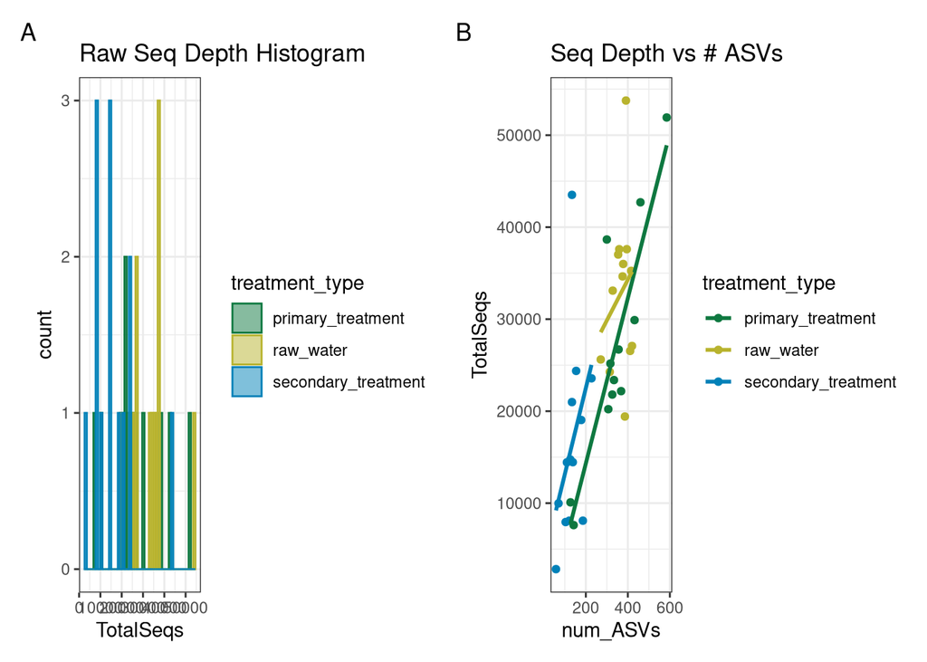

```r
# Combine plots
rawSeq_histogram + rawSeq_vs_numASV_plot +
  patchwork::plot_annotation(tag_levels = "A")
```

Normalizing to lowest count.

Due to treatment types largely affecting the richness of the samples there are fewer sequences in the ‘secondary_treatment’ samples, this will skew the data, but shoud work for our purposes. Once Normalized B-dispr tests can still be performed accurately.

# Scale Read Counts

```r
min(sample_sums(midpoint_rooted_physeq))
```

```
## [1] 2828
```

```r
scaled_physeq <-
  midpoint_rooted_physeq %>%
  scale_reads(round = "matround")

# Confirm seq read depth of scaled_physeq
scaled_TotalSeqs_df <-
  scaled_physeq %>%
  sample_sums() %>%
  data.frame()

colnames(scaled_TotalSeqs_df)[1] <- "TotalSeqs"

# add a new column of num_ASVs (RAW, non-noramlized # ASVs)
scaled_TotalSeqsASVs_df <-
  scaled_TotalSeqs_df %>%
  mutate(num_ASVs = colSums(otu_table(scaled_physeq) > 1))

scaled_TotalSeqsASVs_df <- scaled_TotalSeqsASVs_df %>%
  tibble::rownames_to_column(var = "names") %>%
  left_join(metadata_df, by = "names")

# Plot it!
scaledSeq_histogram <-
  scaled_TotalSeqs_df %>%
  ggplot(aes(x = TotalSeqs)) +
  geom_histogram(bins = 50) +
  labs(title = "Scaled Seq Depth Histogram") +
  scale_x_continuous(limits = c(0, 7000)) +
  theme_bw()

# Scaling always gives us a range!
# MInimum sequences
min(scaled_TotalSeqs_df$TotalSeqs)
```

```
## [1] 2808
```

```r
# How many is that range?
range_seqs <- (max(scaled_TotalSeqs_df$TotalSeqs) - min(scaled_TotalSeqs_df$TotalSeqs))
range_seqs
```

```
## [1] 26
```

```r
# And in terms of percent?
range_seqs/max(scaled_TotalSeqs_df$TotalSeqs)
```

```
## [1] 0.009174312
```

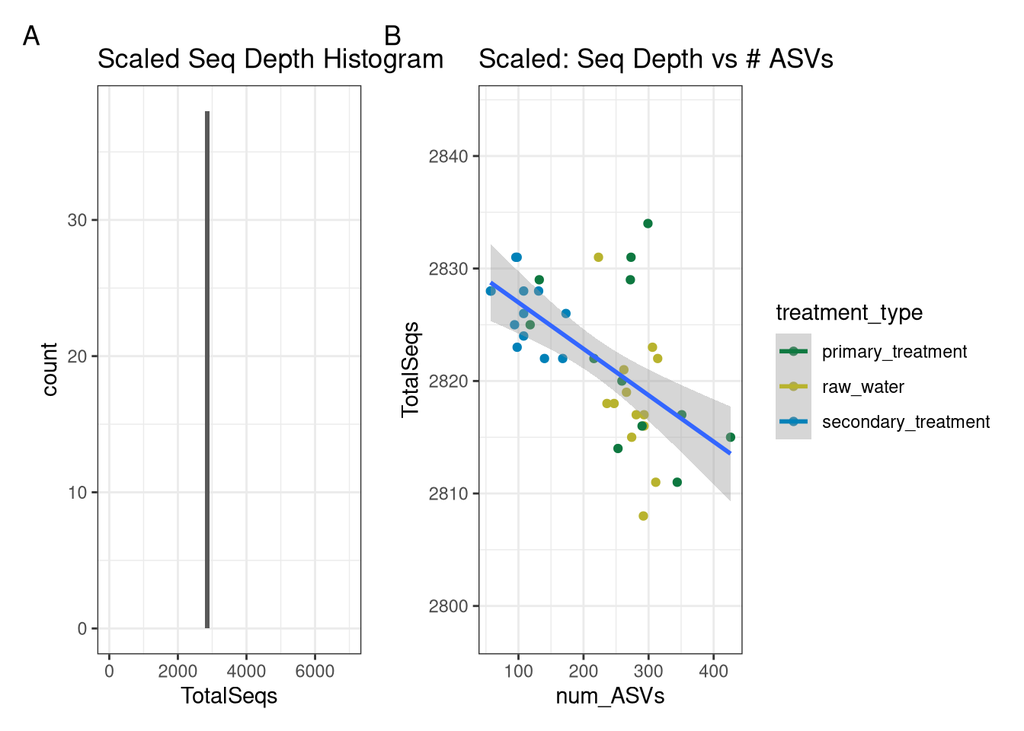

```r
# Set the axis min and max for the next plot
max_y <- max(scaled_TotalSeqs_df$TotalSeqs) + 10
min_y <- min(scaled_TotalSeqs_df$TotalSeqs) - 10

# Now, draw the plot
scaledSeq_vs_numASV_plot <-
  scaled_TotalSeqsASVs_df %>%
  ggplot(aes(x = num_ASVs, y = TotalSeqs, color = treatment_type)) +
  geom_point() +
  geom_smooth(method = "lm", aes(group = 1)) +  # Apply smoothing to the whole dataset
  scale_y_continuous(limits = c(min_y, max_y)) +
  scale_color_manual(values = treatment_colors) +
  theme_bw() +
  labs(title = "Scaled: Seq Depth vs # ASVs")
# Put the two plots together.
scaledSeq_histogram + scaledSeq_vs_numASV_plot +
  plot_annotation(tag_levels = "A")
```

# Beta Diversity Metrics

### Question:

How do different mussel community compositions (native, invasive, mixed), affect the bacterial community composition and load of wastewater effluent?

Looking at total counts and relative abundances of potentially harmful wastewater taxa.

### Want to Look at:

- relative abundances
- phylogenetic makeup/differences of communities

### Measures to Use:

- Jaccard = how unique are samples w/o abundance
- Bray-Curtis = how unique are samples w/ abundance weighting
- Weighted UniFrac = how unique are samples phylogenetically x abundance
- Unweighted Unifrac= how usique are samples phylogenetically

```r
# Bray-Curtis Dissimiliarty
scaled_bray_dist <- phyloseq::distance(scaled_physeq, method = "bray", binary = FALSE)
# weighted unifrac
scaled_wUnifrac_dist <- phyloseq::distance(scaled_physeq, method = "wunifrac")
# Jaccard Dissimiliarty
scaled_jaccard_dist <- phyloseq::distance(scaled_physeq, method = "jaccard", binary = FALSE)
#unweighted unifrac
scaled_uUnifrac_dist <- phyloseq::distance(scaled_physeq, method = "uunifrac")
scaled_uUnifrac_dist_matrix <- as.matrix(scaled_uUnifrac_dist)
```

```r
# bray curtis treatment
bray_treatment_adonis_terms1 <- adonis2(scaled_bray_dist ~ treatment_type + mussle_community_composition, data = metadata_df, by = "terms")
bray_treatment_adonis_terms1
```

```
## Permutation test for adonis under reduced model
## Terms added sequentially (first to last)
## Permutation: free
## Number of permutations: 999
##
## adonis2(formula = scaled_bray_dist ~ treatment_type + mussle_community_composition, data = metadata_df, by = "terms")
##                              Df SumOfSqs      R2       F Pr(>F)
## treatment_type                2   5.1457 0.42897 13.4798  0.001 ***
## mussle_community_composition  3   0.7420 0.06186  1.2958  0.188
## Residual                     32   6.1078 0.50917
## Total                        37  11.9955 1.00000
## ---
## Signif. codes:  0 '***' 0.001 '**' 0.01 '*' 0.05 '.' 0.1 ' ' 1
```

```r
#wUnifrac treatment
wUnifrac_treatment_adonis_terms1 <- adonis2(scaled_wUnifrac_dist ~ treatment_type + mussle_community_composition , data = metadata_df, by = "terms")
wUnifrac_treatment_adonis_terms1
```

```
## Permutation test for adonis under reduced model
## Terms added sequentially (first to last)
## Permutation: free
## Number of permutations: 999
##
## adonis2(formula = scaled_wUnifrac_dist ~ treatment_type + mussle_community_composition, data = metadata_df, by = "terms")
##                              Df SumOfSqs      R2       F Pr(>F)
## treatment_type                2   2.1442 0.65246 33.7770  0.001 ***
## mussle_community_composition  3   0.1264 0.03847  1.3276  0.216
## Residual                     32   1.0157 0.30907
## Total                        37   3.2863 1.00000
## ---
## Signif. codes:  0 '***' 0.001 '**' 0.01 '*' 0.05 '.' 0.1 ' ' 1
```

```r
#jaccard treatment
jaccard_treatment_adonis_terms1 <- adonis2(scaled_jaccard_dist ~ treatment_type  + mussle_community_composition , data = metadata_df, by = "terms")
jaccard_treatment_adonis_terms1
```

```
## Permutation test for adonis under reduced model
## Terms added sequentially (first to last)
## Permutation: free
## Number of permutations: 999
##
## adonis2(formula = scaled_jaccard_dist ~ treatment_type + mussle_community_composition, data = metadata_df, by = "terms")
##                              Df SumOfSqs      R2      F Pr(>F)
## treatment_type                2   4.1979 0.30590 7.8784  0.001 ***
## mussle_community_composition  3   1.0000 0.07287 1.2511  0.145
## Residual                     32   8.5254 0.62124
## Total                        37  13.7233 1.00000
## ---
## Signif. codes:  0 '***' 0.001 '**' 0.01 '*' 0.05 '.' 0.1 ' ' 1
```

```r
#uUnifrac treatment
uUnifrac_treatment_adonis_terms1 <- adonis2(scaled_uUnifrac_dist ~ treatment_type + mussle_community_composition , data = metadata_df, by = "terms")
uUnifrac_treatment_adonis_terms1
```

```
## Permutation test for adonis under reduced model
## Terms added sequentially (first to last)
## Permutation: free
## Number of permutations: 999
##
## adonis2(formula = scaled_uUnifrac_dist ~ treatment_type + mussle_community_composition, data = metadata_df, by = "terms")
##                              Df SumOfSqs      R2       F Pr(>F)
## treatment_type                2   3.7010 0.41158 13.7276  0.001 ***
## mussle_community_composition  3   0.9776 0.10872  2.4174  0.007 **
## Residual                     32   4.3136 0.47971
## Total                        37   8.9921 1.00000
## ---
## Signif. codes:  0 '***' 0.001 '**' 0.01 '*' 0.05 '.' 0.1 ' ' 1
```

```r
# bray curtis mussels
bray_mussel_adonis_terms1 <- adonis2(scaled_bray_dist ~  mussle_community_composition + treatment_type, data = metadata_df, by = "terms")
bray_mussel_adonis_terms1
```

```
## Permutation test for adonis under reduced model
## Terms added sequentially (first to last)
## Permutation: free
## Number of permutations: 999
##
## adonis2(formula = scaled_bray_dist ~ mussle_community_composition + treatment_type, data = metadata_df, by = "terms")
##                              Df SumOfSqs      R2       F Pr(>F)
## mussle_community_composition  3   0.7586 0.06324  1.3249  0.174
## treatment_type                2   5.1291 0.42759 13.4362  0.001 ***
## Residual                     32   6.1078 0.50917
## Total                        37  11.9955 1.00000
## ---
## Signif. codes:  0 '***' 0.001 '**' 0.01 '*' 0.05 '.' 0.1 ' ' 1
```

```r
# wunifrac mussels
wUnifrac_mussel_adonis_terms1 <- adonis2(scaled_wUnifrac_dist ~ mussle_community_composition + treatment_type, data = metadata_df, by = "terms")
wUnifrac_mussel_adonis_terms1
```

```
## Permutation test for adonis under reduced model
## Terms added sequentially (first to last)
## Permutation: free
## Number of permutations: 999
##
## adonis2(formula = scaled_wUnifrac_dist ~ mussle_community_composition + treatment_type, data = metadata_df, by = "terms")
##                              Df SumOfSqs      R2       F Pr(>F)
## mussle_community_composition  3   0.1299 0.03954  1.3646  0.238
## treatment_type                2   2.1407 0.65139 33.7216  0.001 ***
## Residual                     32   1.0157 0.30907
## Total                        37   3.2863 1.00000
## ---
## Signif. codes:  0 '***' 0.001 '**' 0.01 '*' 0.05 '.' 0.1 ' ' 1
```

```r
# jaccard mussels
jaccard_mussel_adonis_terms1 <- adonis2(scaled_jaccard_dist ~ mussle_community_composition + treatment_type, data = metadata_df, by = "terms")
jaccard_mussel_adonis_terms1
```

```
## Permutation test for adonis under reduced model
## Terms added sequentially (first to last)
## Permutation: free
## Number of permutations: 999
##
## adonis2(formula = scaled_jaccard_dist ~ mussle_community_composition + treatment_type, data = metadata_df, by = "terms")
##                              Df SumOfSqs      R2      F Pr(>F)
## mussle_community_composition  3   1.0167 0.07408 1.2720  0.126
## treatment_type                2   4.1813 0.30468 7.8471  0.001 ***
## Residual                     32   8.5254 0.62124
## Total                        37  13.7233 1.00000
## ---
## Signif. codes:  0 '***' 0.001 '**' 0.01 '*' 0.05 '.' 0.1 ' ' 1
```

```r
#uunifrac mussels
uUnifrac_mussel_adonis_terms1 <- adonis2(scaled_uUnifrac_dist ~ mussle_community_composition + treatment_type, data = metadata_df, by = "terms")
uUnifrac_mussel_adonis_terms1
```

```
## Permutation test for adonis under reduced model
## Terms added sequentially (first to last)
## Permutation: free
## Number of permutations: 999
##
## adonis2(formula = scaled_uUnifrac_dist ~ mussle_community_composition + treatment_type, data = metadata_df, by = "terms")
##                              Df SumOfSqs      R2       F Pr(>F)
## mussle_community_composition  3   0.9741 0.10833  2.4088  0.003 **
## treatment_type                2   3.7045 0.41197 13.7406  0.001 ***
## Residual                     32   4.3136 0.47971
## Total                        37   8.9921 1.00000
## ---
## Signif. codes:  0 '***' 0.001 '**' 0.01 '*' 0.05 '.' 0.1 ' ' 1
```

## Statistical Interpretation

Moving forward will be testing WUnifrac and UUnifrac which have the highest percentage of data explained their respective groups: - WUnifrac - treatment type (~65%) - UUnifrac - mussel community (~10%)

# Interpreting PERMANOVA w/ Betadispr

```r
# wunifrac treatment
dispr_wunifrac_treatment <- betadisper(scaled_wUnifrac_dist, metadata_df$treatment_type)
permutest(dispr_wunifrac_treatment)
```

```
##
## Permutation test for homogeneity of multivariate dispersions
## Permutation: free
## Number of permutations: 999
##
## Response: Distances
##           Df  Sum Sq  Mean Sq      F N.Perm Pr(>F)
## Groups     2 0.16816 0.084080 7.2064    999  0.001 ***
## Residuals 35 0.40836 0.011667
## ---
## Signif. codes:  0 '***' 0.001 '**' 0.01 '*' 0.05 '.' 0.1 ' ' 1
```

```r
# uunifrac treatment
dispr_uunifrac_treatment <- betadisper(scaled_uUnifrac_dist, metadata_df$treatment_type)
permutest(dispr_uunifrac_treatment)
```

```
##
## Permutation test for homogeneity of multivariate dispersions
## Permutation: free
## Number of permutations: 999
##
## Response: Distances
##           Df   Sum Sq   Mean Sq      F N.Perm Pr(>F)
## Groups     2 0.024539 0.0122693 1.4564    999  0.235
## Residuals 35 0.294846 0.0084242
```

```r
# wunifrac mussels
dispr_wunifrac_mussels <- betadisper(scaled_wUnifrac_dist, metadata_df$mussle_community_composition)
permutest(dispr_wunifrac_mussels)
```

```
##
## Permutation test for homogeneity of multivariate dispersions
## Permutation: free
## Number of permutations: 999
##
## Response: Distances
##           Df  Sum Sq  Mean Sq      F N.Perm Pr(>F)
## Groups     3 0.04043 0.013475 0.2651    999  0.849
## Residuals 34 1.72791 0.050821
```

```r
# uunifrac treatment
dispr_uunifrac_mussels <- betadisper(scaled_uUnifrac_dist, metadata_df$mussle_community_composition)
permutest(dispr_uunifrac_mussels)
```

```
##
## Permutation test for homogeneity of multivariate dispersions
## Permutation: free
## Number of permutations: 999
##
## Response: Distances
##           Df  Sum Sq  Mean Sq      F N.Perm Pr(>F)
## Groups     3 0.00682 0.002274 0.0957    999  0.959
## Residuals 34 0.80748 0.023749
```

## Statistical Interpretation

Only Weighted Unifrac of the Treatment type yeilded significant dispersion of samples. This means that there may be other factors at play with the Treatment type leading to increased dispersion of samples.

All other tests performed: unwieghted unifrac of treatment and mussel composition and weighted unifrac of mussel composition did not show significant dispersion.

# PCoA

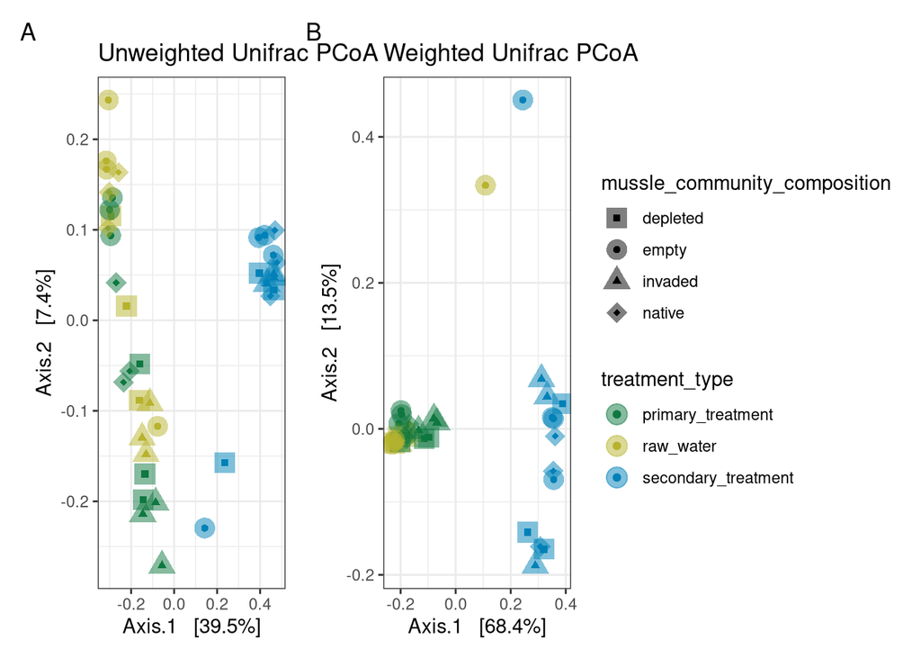

```r
## UUNIFRAC
# First, calculate PCoA with uunifrac
scaled_uunifrac_pcoa <-
  ordinate(physeq = scaled_physeq,
           method = "PCoA",
           distance = "uunifrac")

# Plot it: Uunifrac PCoA
uunifrac_pcoa_plot <-
  plot_ordination(physeq = scaled_physeq,
                  ordination = scaled_uunifrac_pcoa,
                  color = "treatment_type",
                  shape = "mussle_community_composition",
                  title = "Unweighted Unifrac PCoA") +
  scale_color_manual(values = treatment_colors) +
  scale_shape_manual(values = c(15, 16, 17,18)) +
  geom_point(size = 5, alpha = 0.5, aes(color = treatment_type)) +
  theme_bw() +
  theme(legend.position = "right")


### WUNIFRAC
# Second, calculate PCoA with WUNIFRAC
scaled_wunifrac_pcoa <-
  ordinate(physeq = scaled_physeq,
           method = "PCoA",
           distance = "wunifrac")

# Plot it: Bray-Curtis PCoA
wunifrac_pcoa_plot <-
  plot_ordination(physeq = scaled_physeq,
                  ordination = scaled_wunifrac_pcoa,
                  color = "treatment_type",
                  shape = "mussle_community_composition",
                  title = "Weighted Unifrac PCoA") +
  scale_color_manual(values = treatment_colors) +
  scale_shape_manual(values = c(15, 16, 17,18)) +
  geom_point(size = 5, alpha = 0.5, aes(color = treatment_type)) +
  theme_bw() +
  theme(legend.position = "right")

# Show the plots
uunifrac_pcoa_plot + wunifrac_pcoa_plot +
  plot_layout(guides = "collect") +
  plot_annotation(tag_levels = "A")
```

From these plots it is hard to show any clear conclusions about Mussel Community composition because there is so much clustering due to treatment types. Will try to remove it as a variable before proceeding to see if there are additional affects which may be at play.

# What would this look like if we split samples by treatment group since we know it affects biological load before introduction to the Mussel Communities?

Using uUnifrac which showed no significant dispersion across samples and the largest portion of the data explained by it (~10%) and using chatGPT to assist in streamlining a loop. I created the following plots attempting to isolate other less important variables.

```r
## I heavily used chatGPT for this (probably very obvious) but I believe finally I have statistically relevant results for analysis

# Empty lists for plots and permanova results
treatment_pcoa_plots <- list()
permanova_results <- list()
dispersion_results <- list()


# Loop over each unique treatment type
for (treatment in unique(sample_data(scaled_physeq)$treatment_type)) {

  # Subset phyloseq object for this treatment group
  physeq_subset <- subset_samples(scaled_physeq, treatment_type == treatment)

  # Skip if fewer than 2 samples (distance & PERMANOVA need at least 2)
  if (nsamples(physeq_subset) < 2) {
    message("Skipping ", treatment, ": less than 2 samples.")
    next
  }

  # Calculate Unweighted UniFrac distance
  dist_matrix <- phyloseq::distance(physeq_subset, method = "uunifrac")

  # Perform PCoA
  treatment_pcoa <- ordinate(physeq_subset, method = "PCoA", distance = dist_matrix)

    # Get metadata for PERMANOVA
  metadata_subset <- as(sample_data(physeq_subset), "data.frame")

  # Run PERMANOVA (note: no treatment_type in model, only mussel composition!)
  permanova <- adonis2(dist_matrix ~ mussle_community_composition,
                                            data = metadata_subset,
                                            permutations = 999)

  permanova_results[[treatment]] <- permanova
  permanova_p <- signif(permanova$`Pr(>F)`[1], 3)

  # Run Beta Dispersion test
  dispr <- betadisper(dist_matrix, metadata_subset$mussle_community_composition)
  disp_result <- permutest(dispr, permutations = 999)
  dispersion_results[[treatment]] <- disp_result

  # Extract p-value
  p_value <- permanova$`Pr(>F)`[1]
  dispersion_p <- signif(disp_result$tab$`Pr(>F)`[1], 3)

  # Create the plot
  pcoa_plot <- plot_ordination(physeq_subset,
                             ordination = treatment_pcoa,
                             color = "mussle_community_composition",
                             title = paste("Unweighted UniFrac PCoA -", treatment)) +
  geom_point(size = 5, alpha = 0.5, aes(color = mussle_community_composition)) +
  scale_color_manual(values = community_colors) +
  theme_bw() +
  theme(legend.position = "right") +
    annotate("text",
             x = Inf, y = Inf,
             label = paste0("PERMANOVA Mussel Community Composition p = ", permanova_p,
                            "\nDispersion Mussel Community Composition p = ", dispersion_p),
             hjust = 1.1, vjust = 1.5,
             size = 3)

  # Store plot
  treatment_pcoa_plots[[treatment]] <- pcoa_plot


}

# Print PERMANOVA Results
print(permanova_results)
```

```
## $raw_water
## Permutation test for adonis under reduced model
## Permutation: free
## Number of permutations: 999
##
## adonis2(formula = dist_matrix ~ mussle_community_composition, data = metadata_subset, permutations = 999)
##          Df SumOfSqs      R2      F Pr(>F)
## Model     3  0.65599 0.40834 2.0705  0.002 **
## Residual  9  0.95050 0.59166
## Total    12  1.60650 1.00000
## ---
## Signif. codes:  0 '***' 0.001 '**' 0.01 '*' 0.05 '.' 0.1 ' ' 1
##
## $secondary_treatment
## Permutation test for adonis under reduced model
## Permutation: free
## Number of permutations: 999
##
## adonis2(formula = dist_matrix ~ mussle_community_composition, data = metadata_subset, permutations = 999)
##          Df SumOfSqs      R2      F Pr(>F)
## Model     3  0.68323 0.31228 1.3623   0.02 *
## Residual  9  1.50461 0.68772
## Total    12  2.18784 1.00000
## ---
## Signif. codes:  0 '***' 0.001 '**' 0.01 '*' 0.05 '.' 0.1 ' ' 1
##
## $primary_treatment
## Permutation test for adonis under reduced model
## Permutation: free
## Number of permutations: 999
##
## adonis2(formula = dist_matrix ~ mussle_community_composition, data = metadata_subset, permutations = 999)
##          Df SumOfSqs      R2      F Pr(>F)
## Model     3  0.74294 0.49633 2.6278  0.001 ***
## Residual  8  0.75392 0.50367
## Total    11  1.49686 1.00000
## ---
## Signif. codes:  0 '***' 0.001 '**' 0.01 '*' 0.05 '.' 0.1 ' ' 1
```

```r
print(dispersion_results)
```

```
## $raw_water
##
## Permutation test for homogeneity of multivariate dispersions
## Permutation: free
## Number of permutations: 999
##
## Response: Distances
##           Df   Sum Sq  Mean Sq      F N.Perm Pr(>F)
## Groups     3 0.019527 0.006509 0.3867    999  0.828
## Residuals  9 0.151478 0.016831
##
## $secondary_treatment
##
## Permutation test for homogeneity of multivariate dispersions
## Permutation: free
## Number of permutations: 999
##
## Response: Distances
##           Df   Sum Sq   Mean Sq     F N.Perm Pr(>F)
## Groups     3 0.068526 0.0228421 2.551    999  0.056 .
## Residuals  9 0.080586 0.0089541
## ---
## Signif. codes:  0 '***' 0.001 '**' 0.01 '*' 0.05 '.' 0.1 ' ' 1
##
## $primary_treatment
##
## Permutation test for homogeneity of multivariate dispersions
## Permutation: free
## Number of permutations: 999
##
## Response: Distances
##           Df   Sum Sq   Mean Sq      F N.Perm Pr(>F)
## Groups     3 0.019665 0.0065550 1.9939    999  0.188
## Residuals  8 0.026301 0.0032876
```

[figure not shown]

```r
ordered_pcoa_plots <- list(
  treatment_pcoa_plots[["raw_water"]],
  treatment_pcoa_plots[["primary_treatment"]],
  treatment_pcoa_plots[["secondary_treatment"]]
)

# Combine and display all the plots for each treatment type
wrap_plots(ordered_pcoa_plots) +
  plot_annotation(tag_levels = "A")
```

Once we removed Treatment_type as a variable clearer clustering can be seen across the groupings of mussel community composition. I am unsure if this is statistically significant as I removed a strongly affecing variable, but now we can see clearer the picture the original authors attempted to report. Perhaps NMDS will provide additional insight into what is happening.

# NMDS

```r
# Unweighted UniFrac NMDS
scaled_uunifrac_nmds <-
  ordinate(physeq = scaled_physeq,
           method = "NMDS",
           distance = "uunifrac")
```

```
## *** Best solution repeated 1 times
```

```r
# Extract stress value for Unweighted UniFrac NMDS
stress_uunifrac <- scaled_uunifrac_nmds$stress

# Plot it: Unweighted UniFrac NMDS
uunifrac_nmds_plot_group <-
  plot_ordination(physeq = scaled_physeq,
                  ordination = scaled_uunifrac_nmds,
                  color = "treatment_type",
                  shape = "mussle_community_composition",
                  title = paste("Unweighted UniFrac NMDS (Stress =", round(stress_uunifrac, 3), ")")) +
  scale_color_manual(values = treatment_colors) +
  scale_shape_manual(values = c(15, 16, 17, 18)) +
  geom_point(size = 5, alpha = 0.5, aes(color = treatment_type)) +
  theme_bw() +
  theme(legend.position = "right")

### Weighted UniFrac NMDS
# Calculate PCoA with Weighted UniFrac
scaled_wunifrac_nmds <-
  ordinate(physeq = scaled_physeq,
           method = "NMDS",
           distance = "wunifrac")
```

```
## *** Best solution repeated 7 times
```

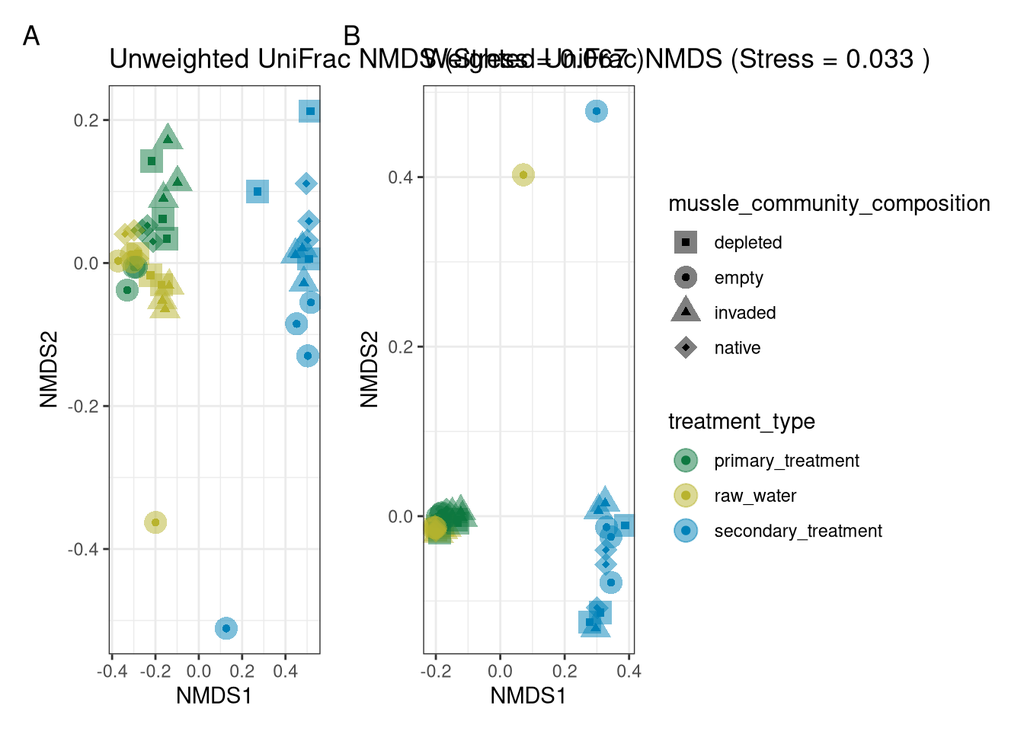

```r
# Extract stress value for Weighted UniFrac NMDS
stress_wunifrac <- scaled_wunifrac_nmds$stress

# Plot it: Weighted UniFrac NMDS
wunifrac_nmds_plot_group <-
  plot_ordination(physeq = scaled_physeq,
                  ordination = scaled_wunifrac_nmds,
                  color = "treatment_type",
                  shape = "mussle_community_composition",
                  title = paste("Weighted UniFrac NMDS (Stress =", round(stress_wunifrac, 3), ")")) +
  scale_color_manual(values = treatment_colors) +
  scale_shape_manual(values = c(15, 16, 17, 18)) +
  geom_point(size = 5, alpha = 0.5, aes(color = treatment_type)) +
  theme_bw() +
  theme(legend.position = "right")

# Show the plots
uunifrac_nmds_plot_group + wunifrac_nmds_plot_group +
  plot_layout(guides = "collect") +
  plot_annotation(tag_levels = "A")
```

```r
# Initialize list to store NMDS plots
nmds_plots <- list()

# Loop over each unique treatment type
for (treatment in unique(sample_data(scaled_physeq)$treatment_type)) {

  # Subset the phyloseq object for the current treatment type
  physeq_subset <- subset_samples(scaled_physeq, treatment_type == treatment)

  # Unweighted UniFrac NMDS
  scaled_uunifrac_nmds <-
    ordinate(physeq = physeq_subset,
             method = "NMDS",
             distance = "uunifrac")

  # Extract stress value for Unweighted UniFrac NMDS
  stress_uunifrac <- scaled_uunifrac_nmds$stress

  # Plot it: Unweighted UniFrac NMDS without treatment_type coloring
  uunifrac_nmds_plot <-
    plot_ordination(physeq = physeq_subset,
                    ordination = scaled_uunifrac_nmds,
                    shape = "mussle_community_composition",
                    title = paste("Unweighted UniFrac NMDS -", treatment,
                                  "(Stress =", round(stress_uunifrac, 3), ")")) +
   geom_point(size = 5, alpha = 0.5, aes(color = mussle_community_composition)) +
  scale_color_manual(values = community_colors) +
    scale_shape_manual(values = c(15, 16, 17, 18)) +
    theme_bw() +
    theme(legend.position = "right") +
    guides(color = "none")

  # Store the plot in the list
  nmds_plots[[treatment]] <- uunifrac_nmds_plot

  ### Weighted UniFrac NMDS
  # Calculate PCoA with Weighted UniFrac
  scaled_wunifrac_nmds <-
    ordinate(physeq = physeq_subset,
             method = "NMDS",
             distance = "wunifrac")

  # Extract stress value for Weighted UniFrac NMDS
  stress_wunifrac <- scaled_wunifrac_nmds$stress

  # Plot it: Weighted UniFrac NMDS without treatment_type coloring
   wunifrac_nmds_plot <-
    plot_ordination(physeq = physeq_subset,
                    ordination = scaled_wunifrac_nmds,
                    shape = "mussle_community_composition",
                    title = paste("Weighted UniFrac NMDS -", treatment,
                                  "(Stress =", round(stress_wunifrac, 3), ")")) +
    geom_point(size = 5, alpha = 0.5, aes(color = mussle_community_composition)) +
    scale_color_manual(values = community_colors) +
    scale_shape_manual(values = c(15, 16, 17, 18)) +
    theme_bw() +
    theme(legend.position = "right") +
    guides(color = "none")

  # Store the plot in the list
  nmds_plots[[paste(treatment, "_wunifrac")]] <- wunifrac_nmds_plot
}
```

```
## *** Best solution repeated 6 times
## *** Best solution repeated 4 times
```

```
## *** Best solution repeated 8 times
```

```
## *** Best solution repeated 6 times
```

```
## *** Best solution repeated 12 times
## *** Best solution repeated 1 times
```

[figure not shown]

```r
ordered_nmds_plots <- list(
  nmds_plots[["raw_water"]],
  nmds_plots[["primary_treatment"]],
  nmds_plots[["secondary_treatment"]],
  nmds_plots[["raw_water _wunifrac"]],
  nmds_plots[["primary_treatment _wunifrac"]],
  nmds_plots[["secondary_treatment _wunifrac"]]
)
# Combine and display all the plots for each treatment type
wrap_plots(ordered_nmds_plots) +
  plot_annotation(tag_levels = "A")
```

This method only worked for Primary Treatment Treated water where one can see distinct clusters. In all other methods there is not enough information without the treatment confounding variable. This makes biological sense as the secondary treatment would remove a large portion of biological load, thus what it leaves behind is largely a product of the treatment method regardless of Mussel COmmunity.

# Final Analysis

[figure not shown]

```r
# select out unweighted/weighted primary treatmend NMDS plots from NMDS plots
selected_ordered_nmds_plots <- list(
  ordered_nmds_plots[[2]],  # raw_water NMDS
  ordered_nmds_plots[[5]]   # primary_treatment NMDS
)

wrap_plots(ordered_pcoa_plots) + uunifrac_nmds_plot_group+ selected_ordered_nmds_plots +
  plot_annotation(tag_levels = "A")
```

With treatment as a counfounding variable it is hard to pinpoint the exact role that the mussel community composition played in the bacterial community’s abundance and phylogenetics. When attempting to remove it, we begin to see a clearer picture, but without the proper datapoints in the metadata to find additional contributors of these differences, one can only speculate to what degree these communities may make an impact.

# Final Info for Reproducibility

```r
end_time <- Sys.time()
end_time
```

```
## [1] "2025-04-22 17:09:28 EDT"
```

```r
elapsed_time <- round((end_time - start_time), 3)
elapsed_time
```

```
## Time difference of 17.026 secs
```